# TidyTuesday, startrek with workflowsets

Following Julia Silge’s analysis

Nicholas Spyrison

06 Mar 2022

# Gist

I am using this as an intro to **tidymodels** and **workflowsets**. I am following along with Julia Silge’s analysis and video post. See https://juliasilge.com/blog/star-trek/ for the blog and video.

# Setup

```r
if(F){
  install.packages(c("tidyverse", "tidymodels", "tidytext", "tidylo"))
  install.packages(c("textrecipes", "themis", "stopwords", "discrim"))
  install.packages(c("naivebayes", "LiblineaR"))
}


library(tidyverse)
computer_raw <- read_csv("https://raw.githubusercontent.com/rfordatascience/tidytuesday/master/data/2021/2021-08-17/computer.csv")
## Missingness by column
is.na(computer_raw) %>% colSums()
```

```
##        name        char        line   direction        type    pri_type
##           0           0           0        1167           0           0
##      domain  sub_domain     nv_resp interaction   char_type      is_fed
##         252         754           0           0           0           0
##       error    value_id
##           0           0
```

```r
if(F) ## Don't print a visual of this.
  naniar::vis_miss(computer_raw)

## Count table; count of unique words by char_type
computer_raw %>%
  distinct(value_id, .keep_all = TRUE) %>%
  count(char_type)
```

```
## # A tibble: 2 x 2
##   char_type     n
##   <chr>     <int>
## 1 Computer    178
## 2 Person      234
```

Which words are more likely to be spoken by a computer vs. by a person?

```r
library(tidytext)
library(tidylo)
```

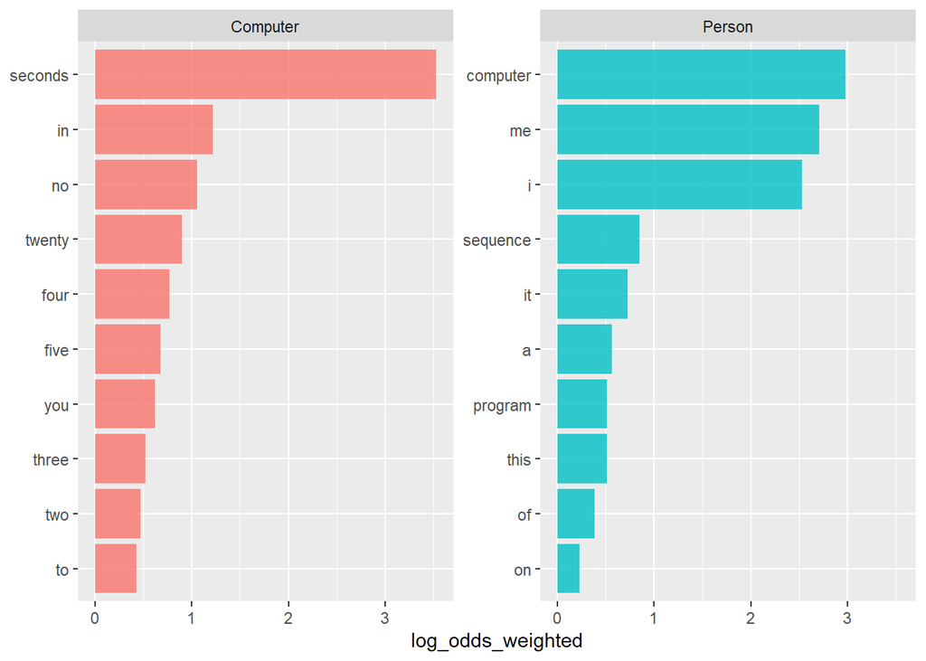

```r
## Finding the top words by char type:
computer_counts <-
  computer_raw %>%
  distinct(value_id, .keep_all = TRUE) %>%
  unnest_tokens(word, interaction) %>%
  count(char_type, word, sort = TRUE)

computer_counts %>%
  bind_log_odds(char_type, word, n) %>%
  filter(n > 10) %>%
  group_by(char_type) %>%
  slice_max(log_odds_weighted, n = 10) %>%
  ungroup() %>%
  ggplot(aes(log_odds_weighted,
    fct_reorder(word, log_odds_weighted),
    fill = char_type
  )) +
  geom_col(alpha = 0.8, show.legend = FALSE) +
  facet_wrap(vars(char_type), scales = "free_y") +
  labs(y = NULL)
```

Notice that stop words are among the words with highest weighted log odds; they are very informative in this situation.

# Build and compare models

First we need to partition our data into splits. Note that we don’t have much data to work with, but we are going to use a typical 80% split. We’ll also bootstrap in 25 folds to help with this.

```r
library(tidymodels)
set.seed(123)

comp_split <-
  computer_raw %>%
  distinct(value_id, .keep_all = TRUE) %>%
  select(char_type, interaction) %>%
  initial_split(prop = 0.8, strata = char_type)

comp_train <- training(comp_split)
comp_test <- testing(comp_split)

## Bootstrap 25 folds of the data to help with the small size.
set.seed(234)
comp_folds <- bootstraps(comp_train, strata = char_type)
comp_folds
```

```
## # Bootstrap sampling using stratification
## # A tibble: 25 x 2
##    splits            id
##    <list>            <chr>
##  1 <split [329/118]> Bootstrap01
##  2 <split [329/128]> Bootstrap02
##  3 <split [329/134]> Bootstrap03
##  4 <split [329/124]> Bootstrap04
##  5 <split [329/118]> Bootstrap05
##  6 <split [329/116]> Bootstrap06
##  7 <split [329/106]> Bootstrap07
##  8 <split [329/124]> Bootstrap08
##  9 <split [329/121]> Bootstrap09
## 10 <split [329/121]> Bootstrap10
## # ... with 15 more rows
```

When it comes to feature engineering, we don’t know ahead of time if we should remove stop words, or center and scale the predictors, or balance the classes. Let’s create feature engineering recipes that do all of these things so we can compare how they perform.

```r
library(textrecipes)
library(themis)
rec_all <-
  recipe(char_type ~ interaction, data = comp_train) %>%
  step_tokenize(interaction) %>%
  step_tokenfilter(interaction, max_tokens = 80) %>%
  step_tfidf(interaction)

rec_all_norm <-
  rec_all %>%
  step_normalize(all_predictors())

rec_all_smote <-
  rec_all_norm %>%
  step_smote(char_type)

## we can `prep()` just to check if it works
prep(rec_all_smote)
```

```
## Recipe
##
## Inputs:
##
##       role #variables
##    outcome          1
##  predictor          1
##
## Training data contained 329 data points and no missing data.
##
## Operations:
##
## Tokenization for interaction [trained]
## Text filtering for interaction [trained]
## Term frequency-inverse document frequency with interaction [trained]
## Centering and scaling for tfidf_interaction_a, tfidf_interaction_access, ... [trained]
## SMOTE based on char_type [trained]
```

Now let’s do the same with removing stop words.

```r
library("stopwords")
rec_stop <-
  recipe(char_type ~ interaction, data = comp_train) %>%
  step_tokenize(interaction) %>%
  step_stopwords(interaction) %>%
  step_tokenfilter(interaction, max_tokens = 80) %>%
  step_tfidf(interaction)

rec_stop_norm <-
  rec_stop %>%
  step_normalize(all_predictors())

rec_stop_smote <-
  rec_stop_norm %>%
  step_smote(char_type)

## again, let's check it
prep(rec_stop_smote)
```

```
## Recipe
##
## Inputs:
##
##       role #variables
##    outcome          1
##  predictor          1
##
## Training data contained 329 data points and no missing data.
##
## Operations:
##
## Tokenization for interaction [trained]
## Stop word removal for interaction [trained]
## Text filtering for interaction [trained]
## Term frequency-inverse document frequency with interaction [trained]
## Centering and scaling for tfidf_interaction_access, tfidf_interaction_aff... [trained]
## SMOTE based on char_type [trained]
```

Let’s try out two kinds of models that often work well for text data, a support vector machine and a naive Bayes model.

```r
library(discrim)
## Naive Bayes
nb_spec <-
  naive_Bayes() %>%
  set_mode("classification") %>%
  set_engine("naivebayes")

nb_spec
```

```
## Naive Bayes Model Specification (classification)
##
## Computational engine: naivebayes
```

```r
## SVM (linear)
svm_spec <-
  svm_linear() %>%
  set_mode("classification") %>%
  set_engine("LiblineaR")

svm_spec
```

```
## Linear Support Vector Machine Specification (classification)
##
## Computational engine: LiblineaR
```

# Map recipes to models and folds

Now we can put all these together in a [workflowset](https://workflowsets.tidymodels.org/).

```r
comp_models <-
  workflow_set(
    preproc = list(
      all = rec_all,
      all_norm = rec_all_norm,
      all_smote = rec_all_smote,
      stop = rec_stop,
      stop_norm = rec_stop_norm,
      stop_smote = rec_stop_smote
    ),
    models = list(nb = nb_spec, svm = svm_spec),
    cross = TRUE
  )

comp_models
```

```
## # A workflow set/tibble: 12 x 4
##    wflow_id       info             option    result
##    <chr>          <list>           <list>    <list>
##  1 all_nb         <tibble [1 x 4]> <opts[0]> <list [0]>
##  2 all_svm        <tibble [1 x 4]> <opts[0]> <list [0]>
##  3 all_norm_nb    <tibble [1 x 4]> <opts[0]> <list [0]>
##  4 all_norm_svm   <tibble [1 x 4]> <opts[0]> <list [0]>
##  5 all_smote_nb   <tibble [1 x 4]> <opts[0]> <list [0]>
##  6 all_smote_svm  <tibble [1 x 4]> <opts[0]> <list [0]>
##  7 stop_nb        <tibble [1 x 4]> <opts[0]> <list [0]>
##  8 stop_svm       <tibble [1 x 4]> <opts[0]> <list [0]>
##  9 stop_norm_nb   <tibble [1 x 4]> <opts[0]> <list [0]>
## 10 stop_norm_svm  <tibble [1 x 4]> <opts[0]> <list [0]>
## 11 stop_smote_nb  <tibble [1 x 4]> <opts[0]> <list [0]>
## 12 stop_smote_svm <tibble [1 x 4]> <opts[0]> <list [0]>
```

None of these models have any tuning parameters, so next let’s use fit_resamples() to evaluate how each of these combinations of feature engineering recipes and model specifications performs, using our bootstrap resamples.

```r
set.seed(123)
cores_less1 <- parallel::detectCores() - 1
doParallel::registerDoParallel(cores = cores_less1)

tictoc::tic("map fit_resamples")
computer_rs <-
  comp_models %>%
  workflow_map(
    "fit_resamples",
    resamples = comp_folds,
    metrics = metric_set(accuracy, sensitivity, specificity)
  )
tictoc::toc() ## Running locally: 65.6 sec elapsed
```

```
## map fit_resamples: 76.8 sec elapsed
```

We can make a quick high-level visualization of these results.

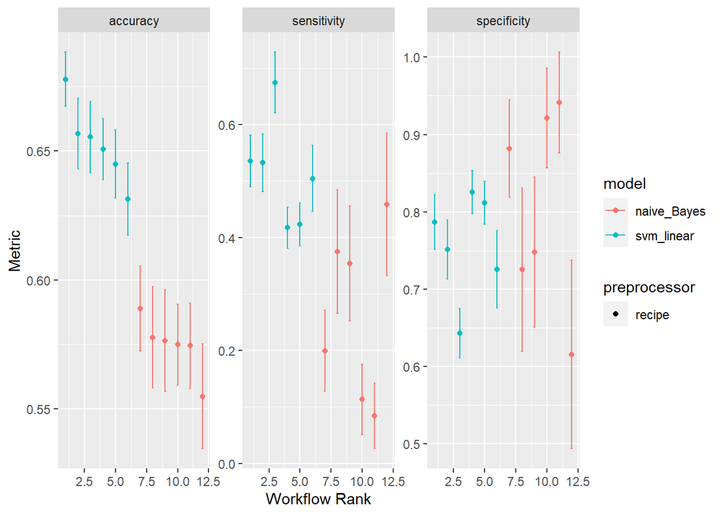

```r
autoplot(computer_rs)
```

All of the SVMs did better than all of the naive Bayes models, at least as far as overall accuracy. We can also dig deeper and explore the results more.

```r
rank_results(computer_rs) %>%
  filter(.metric == "accuracy")
```

```
## # A tibble: 12 x 9
##    wflow_id       .config              .metric   mean std_err     n preprocessor
##    <chr>          <chr>                <chr>    <dbl>   <dbl> <int> <chr>
##  1 all_svm        Preprocessor1_Model1 accuracy 0.678 0.00635    25 recipe
##  2 all_norm_svm   Preprocessor1_Model1 accuracy 0.657 0.00835    25 recipe
##  3 all_smote_svm  Preprocessor1_Model1 accuracy 0.655 0.00844    25 recipe
##  4 stop_svm       Preprocessor1_Model1 accuracy 0.651 0.00721    25 recipe
##  5 stop_norm_svm  Preprocessor1_Model1 accuracy 0.645 0.00799    25 recipe
##  6 stop_smote_svm Preprocessor1_Model1 accuracy 0.631 0.00848    25 recipe
##  7 all_norm_nb    Preprocessor1_Model1 accuracy 0.589 0.00996    25 recipe
##  8 all_nb         Preprocessor1_Model1 accuracy 0.578 0.0119     25 recipe
##  9 all_smote_nb   Preprocessor1_Model1 accuracy 0.576 0.0120     25 recipe
## 10 stop_smote_nb  Preprocessor1_Model1 accuracy 0.575 0.00959    25 recipe
## 11 stop_norm_nb   Preprocessor1_Model1 accuracy 0.575 0.0100     25 recipe
## 12 stop_nb        Preprocessor1_Model1 accuracy 0.555 0.0124     25 recipe
##    model        rank
##    <chr>       <int>
##  1 svm_linear      1
##  2 svm_linear      2
##  3 svm_linear      3
##  4 svm_linear      4
##  5 svm_linear      5
##  6 svm_linear      6
##  7 naive_Bayes     7
##  8 naive_Bayes     8
##  9 naive_Bayes     9
## 10 naive_Bayes    10
## 11 naive_Bayes    11
## 12 naive_Bayes    12
```

Some interesting things to note are:

how balancing the classes via SMOTE does in fact change sensitivity and specificity the way we would expect that removing stop words looks like mostly a bad idea!

# Train and evaluate final model

Let’s say that we want to keep overall accuracy high, so we pick rec_all and svm_spec. We can use `last_fit()` to fit one time to all the training data and evalute one time on the testing data.

```r
comp_wf <- workflow(rec_all, svm_spec)

comp_fitted <-
  last_fit(
    comp_wf,
    comp_split,
    metrics = metric_set(accuracy, sensitivity, specificity)
  )

comp_fitted
```

```
## # Resampling results
## # Manual resampling
## # A tibble: 1 x 6
##   splits           id               .metrics         .notes
##   <list>           <chr>            <list>           <list>
## 1 <split [329/83]> train/test split <tibble [3 x 4]> <tibble [0 x 3]>
##   .predictions      .workflow
##   <list>            <list>
## 1 <tibble [83 x 4]> <workflow>
```

How did that turn out?

```r
collect_metrics(comp_fitted)
```

```
## # A tibble: 3 x 4
##   .metric     .estimator .estimate .config
##   <chr>       <chr>          <dbl> <chr>
## 1 accuracy    binary         0.735 Preprocessor1_Model1
## 2 sensitivity binary         0.639 Preprocessor1_Model1
## 3 specificity binary         0.809 Preprocessor1_Model1
```

We can also look at the predictions, and for example make a confusion matrix.

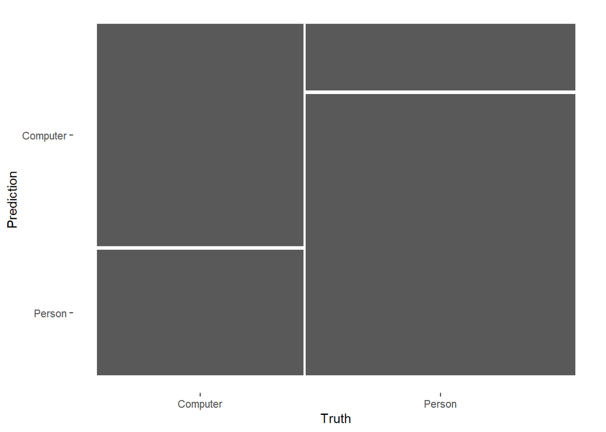

```r
collect_predictions(comp_fitted) %>%
  conf_mat(char_type, .pred_class) %>%
  autoplot()
```

It was easier to identify people talking to computers than the other way around.

Since this is a linear model, we can also look at the coefficients for words in the model, perhaps for the largest effect size terms in each direction.

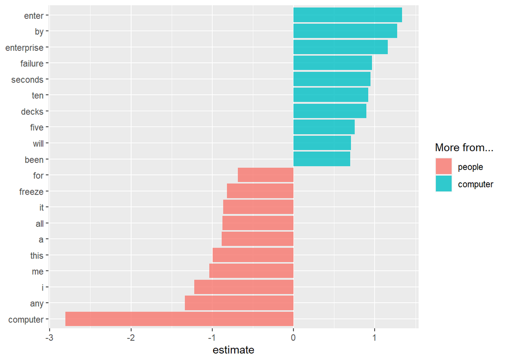

```r
extract_workflow(comp_fitted) %>%
  tidy() %>%
  group_by(estimate > 0) %>%
  slice_max(abs(estimate), n = 10) %>%
  ungroup() %>%
  mutate(term = str_remove(term, "tfidf_interaction_")) %>%
  ggplot(aes(estimate, fct_reorder(term, estimate), fill = estimate > 0)) +
  geom_col(alpha = 0.8) +
  scale_fill_discrete(labels = c("people", "computer")) +
  labs(y = NULL, fill = "More from...")
```

# Session info

```r
## Packages used
pkgs <- c("tidyverse", "tidymodels", "tidytext", "tidylo",
          "textrecipes", "themis", "stopwords", "discrim",
          "naivebayes", "LiblineaR")
## Package & session info
```

# Sources & related content

- https://juliasilge.com/blog/star-trek/
- https://github.com/rfordatascience/tidytuesday/blob/master/data/2021/2021-08-17/readme.md
- https://www.tidymodels.org/
- https://workflowsets.tidymodels.org/
- [Interactive list of parsnip models](https://www.tidymodels.org/find/parsnip/)